title: “Global Effects of Road Development on Land-Use Change” author: “Mateo Gret”

# Introduction

This project examines how land-use change between 1992 and 2010 is spatially associated with existing road networks in three contrasting regions: Northern Kazakhstan, the Brazilian Cerrado, and West Kalimantan (Borneo). The goal is to identify whether areas closer to roads show stronger transitions toward human-dominated land uses.

# Methods

We used GRIP global road data and built-up area layers from the LULC-cube for the years 1992 and 2010. Three 2°×2° regions (Northern Kazakhstan, Brazilian Cerrado, West Kalimantan) were defined as bounding boxes and used to crop all datasets.

Built-up change was calculated as the difference between 2010 and 1992. Road density was derived from the GRIP dataset and resampled to match the land-use grid. For each region, we combined both datasets into a common table containing built-up change, road density, and cell coordinates. These values were used to examine spatial relationships between roads and land-use change.

# Results

## Summary statistics

```r
summary_stats <- read.csv("../figs/summary_stats_regions.csv")
```

[output not shown]

## Built-up change vs. road density

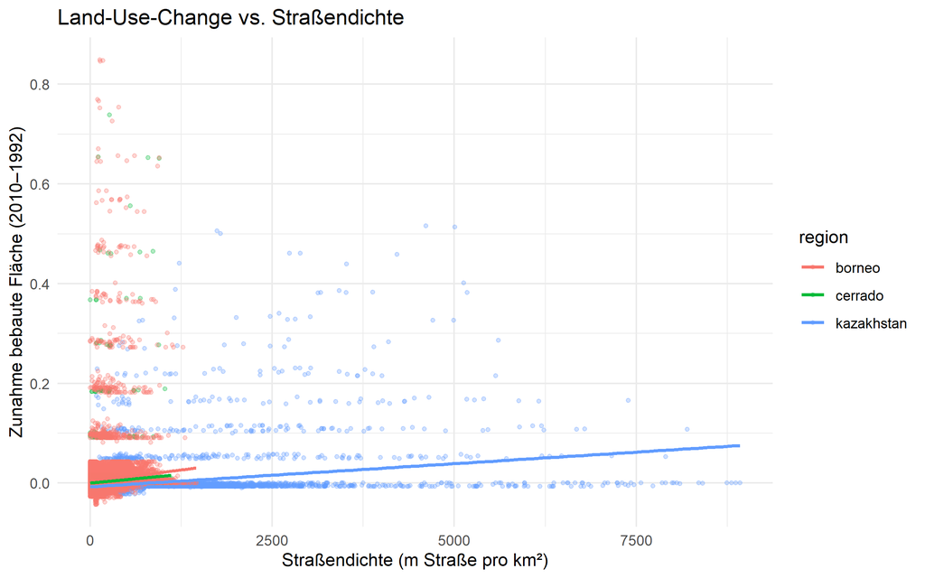

## Distribution of land-use change by region

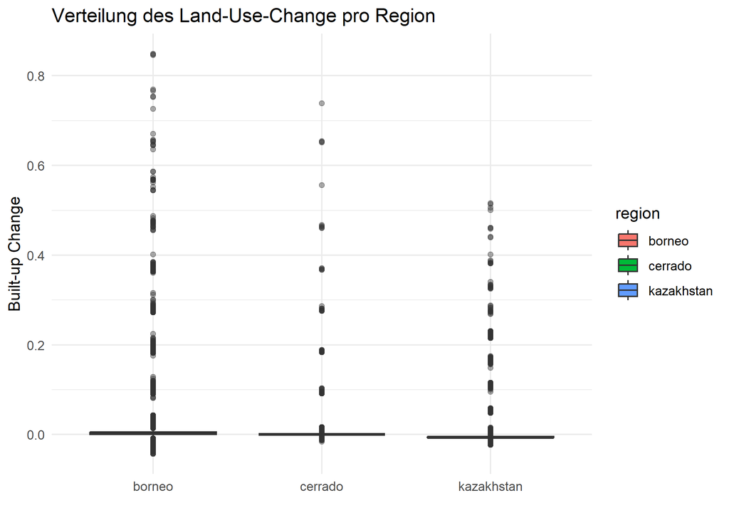

## Regional patterns

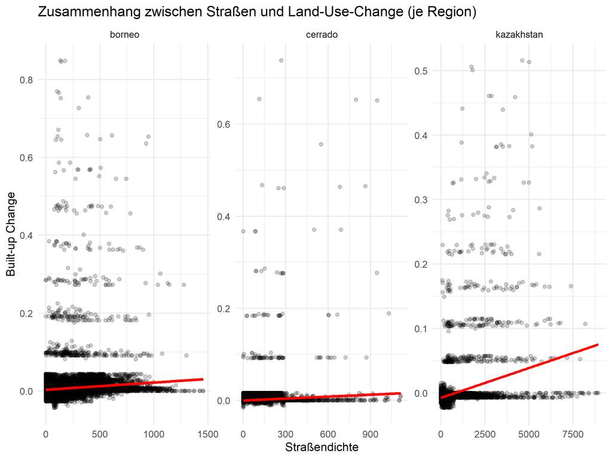

# Discussion